# Índice Sintético de Desigualdad Migratoria (ISDM)

Análisis con agregación jerárquica: Brechas Nativos vs Migrantes Recientes - Argentina y Chile 2015-2024

Natalia Debandi

2026-02-22

# 1 Introducción

Este documento presenta la construcción de un **Índice Sintético de Desigualdad Migratoria (ISDM)** enfocado en las brechas entre **población nativa y migrantes recientes** (5 años o menos en el país) en Argentina y Chile durante el período 2015-2024.

## 1.1 Objetivo: Migrantes recientes vs todos los migrantes

Este análisis complementa el ISDM general (nativos vs todos los migrantes) al enfocarse específicamente en migrantes recientes. Se espera que:

- Las brechas sean **más pronunciadas** para migrantes recientes debido a menor tiempo de integración
- Las diferencias entre países puedan ser **más o menos marcadas** según las políticas de acogida
- Ciertas dimensiones (ej. social) muestren **mayor sensibilidad** al tiempo de residencia

## 1.2 Metodología: Agregación jerárquica por dimensiones

Se utiliza la misma metodología de agregación jerárquica:

### 1.2.1 **Nivel 1: Sub-índices por dimensión**

- **Dimensión Laboral** (5 indicadores)
- **Dimensión Pobreza** (2 indicadores)
- **Dimensión Social** (3 indicadores)

### 1.2.2 **Nivel 2: Agregación final**

ISDM = Promedio de los 3 sub-índices (peso 33.3% cada dimensión)

```r
rm(list = ls())
library(tidyverse)
library(readr)
library(scales)
library(knitr)
library(kableExtra)
library(zoo)

# Operador auxiliar
`%nin%` <- Negate(`%in%`)
```

# 2 Datos y clasificación

recalculo las brechas porque CHILE TIENE SOLO CASEN PARA RECIENTES

```r
# Cargar datos
indicadores_long <- read_csv(
  "Data/indicadores_unificados_arg_chile_2015_2024.csv",
  show_col_types = FALSE
)

# Excluir año 2020 para ambos países (distorsión pandemia)
indicadores_long <- indicadores_long %>%
  filter(anio != 2020)

# Excluir ENE de Chile (solo CASEN tiene datos de migrantes recientes)
indicadores_long <- indicadores_long %>%
  filter(!(pais == "Chile" & fuente == "ENE"))



# Calcular brechas
indicadores <- indicadores_long %>%
  pivot_wider(
    names_from = grupo,
    values_from = valor,
    values_fn = mean
  ) %>%
  mutate(
    brecha_nat_mig =  Nativos-Migrantes,
    brecha_nat_rec = Nativos- `Migrantes recientes`,
    anio = as.integer(anio)
  ) %>%
  filter(!is.na(brecha_nat_mig))  # Eliminar filas sin brecha calculable

# Usar directamente los datos anuales (SIN promediar por período)
indicadores <- indicadores %>%
  select(pais, fuente, anio, indicador, indicador_clean,
         Nativos, Migrantes, `Migrantes recientes`,
         brecha_nat_mig, brecha_nat_rec) %>%
  rename(
    nativos = Nativos,
    migrantes = Migrantes,
    migrantes_recientes = `Migrantes recientes`
  )

# Guardar dataset con brechas recalculadas
#write_csv(indicadores,
#          "Data/indicadores_con_brechas_CASEN_arg_chile_2015_2024.csv")

indicadores_con_brechas <- indicadores

# =============================================================================
# IMPUTACIÓN: interpolación lineal para Chile - todos los indicadores
# (años inter-CASEN: 2018, 2019, 2021, 2023 — sin ENE, faltan todos)
# =============================================================================

# Todos los años del dataset (ambos países) para completar la serie de Chile
anios_todos <- sort(unique(indicadores_con_brechas$anio))

chile_imputado <- indicadores_con_brechas %>%
  filter(pais == "Chile") %>%
  complete(pais, indicador, anio = anios_todos) %>%
  group_by(indicador) %>%
  arrange(anio) %>%
  fill(indicador_clean, .direction = "downup") %>%
  mutate(
    imputado       = is.na(brecha_nat_mig),
    brecha_nat_mig = zoo::na.approx(brecha_nat_mig, na.rm = FALSE),
    brecha_nat_rec = zoo::na.approx(brecha_nat_rec, na.rm = FALSE),
    fuente         = if_else(imputado, "CASEN_interpolado", fuente)
  ) %>%
  ungroup()

cat("Valores imputados por interpolación lineal (Chile - todos los indicadores):\n\n")
```

```
## Valores imputados por interpolación lineal (Chile - todos los indicadores):
```

```r
chile_imputado %>%
  filter(imputado) %>%
  select(indicador, anio, brecha_nat_mig, brecha_nat_rec) %>%
  arrange(indicador, anio) %>%
  print(n = 60)
```

```
## # A tibble: 50 × 4
##    indicador                     anio brecha_nat_mig brecha_nat_rec
##    <chr>                        <int>          <dbl>          <dbl>
##  1 I10_sistema_salud_publico     2016         15.8           15.4
##  2 I10_sistema_salud_publico     2018         13.2           13.2
##  3 I10_sistema_salud_publico     2019         11.6           11.6
##  4 I10_sistema_salud_publico     2021          9.94           9.98
##  5 I10_sistema_salud_publico     2023          3.80           1.00
##  6 I1_tasa_actividad             2016        -21.9          -22.2
##  7 I1_tasa_actividad             2018        -23.0          -23.2
##  8 I1_tasa_actividad             2019        -22.4          -22.5
##  9 I1_tasa_actividad             2021        -21.8          -21.9
## 10 I1_tasa_actividad             2023        -20.0          -17.8
## 11 I2_tasa_desempleo             2016          1.31           1.29
## 12 I2_tasa_desempleo             2018          0.720          0.666
```

[output cut: 38 more lines]

```r
indicadores_con_brechas <- indicadores_con_brechas %>%
  filter(pais != "Chile") %>%
  bind_rows(chile_imputado %>% select(-imputado)) %>%
  arrange(pais, anio, indicador)

cat("\n✓ Imputación completada —", nrow(indicadores_con_brechas), "filas totales\n\n")
```

```
##
## ✓ Imputación completada — 170 filas totales
```

## 2.1 Carga de datos

```r
# Cargar datos
#indicadores_con_brechas <- read_csv(
#  "Data/indicadores_con_brechas_CASEN_arg_chile_2015_2024.csv",
#  show_col_types = FALSE
#)

cat("Dimensiones del dataset:", nrow(indicadores_con_brechas), "filas x",
    ncol(indicadores_con_brechas), "columnas\n\n")
```

```
## Dimensiones del dataset: 170 filas x 10 columnas
```

```r
cat("Países incluidos:", paste(unique(indicadores_con_brechas$pais), collapse = ", "), "\n")
```

```
## Países incluidos: Argentina, Chile
```

```r
cat("Período de análisis:", min(indicadores_con_brechas$anio), "-",
    max(indicadores_con_brechas$anio), "\n")
```

```
## Período de análisis: 2015 - 2024
```

```r
cat("Número de indicadores:", length(unique(indicadores_con_brechas$indicador)), "\n\n")
```

```
## Número de indicadores: 10
```

```r
# Verificar que existen datos de migrantes recientes
cat("Variables disponibles:", paste(names(indicadores_con_brechas), collapse = ", "), "\n\n")
```

```
## Variables disponibles: pais, fuente, anio, indicador, indicador_clean, nativos, migrantes, migrantes_recientes, brecha_nat_mig, brecha_nat_rec
```

```r
# Resumen de disponibilidad de datos para migrantes recientes
disponibilidad <- indicadores_con_brechas %>%
  summarise(
    obs_totales = n(),
    obs_con_mig_recientes = sum(!is.na(migrantes_recientes)),
    obs_con_brecha_rec = sum(!is.na(brecha_nat_rec)),
    pct_disponibilidad = round(sum(!is.na(brecha_nat_rec)) / n() * 100, 1)
  )

cat("DISPONIBILIDAD DE DATOS PARA MIGRANTES RECIENTES:\n")
```

```
## DISPONIBILIDAD DE DATOS PARA MIGRANTES RECIENTES:
```

```r
cat("================================================\n")
cat(sprintf("  • Observaciones totales: %d\n", disponibilidad$obs_totales))
```

```
##   • Observaciones totales: 170
```

```r
cat(sprintf("  • Con datos de migrantes recientes (observados): %d\n", disponibilidad$obs_con_mig_recientes))
```

```
##   • Con datos de migrantes recientes (observados): 120
```

```r
cat(sprintf("  • Con brecha nativos-recientes (obs + imputados): %d\n", disponibilidad$obs_con_brecha_rec))
```

```
##   • Con brecha nativos-recientes (obs + imputados): 170
```

```r
cat(sprintf("  • Porcentaje de disponibilidad: %.1f%%\n\n", disponibilidad$pct_disponibilidad))
```

```
##   • Porcentaje de disponibilidad: 100.0%
```

```r
# Desglose por país y año
cat("COBERTURA POR PAÍS Y AÑO:\n")
```

```
## COBERTURA POR PAÍS Y AÑO:
```

```r
cat("=========================\n\n")
indicadores_con_brechas %>%
  group_by(pais, anio) %>%
  summarise(
    n_indicadores     = n(),
    n_brecha_mig      = sum(!is.na(brecha_nat_mig)),
    n_brecha_rec      = sum(!is.na(brecha_nat_rec)),
    fuente_label      = paste(sort(unique(fuente)), collapse = " + "),
    .groups = "drop"
  ) %>%
  arrange(pais, anio) %>%
  kable(
    caption = "Cobertura de indicadores por país y año (obs = observado, imp = interpolado)",
    col.names = c("País", "Año", "N indicadores",
                  "Brecha nat-mig", "Brecha nat-rec", "Fuente"),
    digits = 0
  ) %>%
  kable_styling(bootstrap_options = c("striped", "hover"), full_width = FALSE) %>%
  row_spec(which(
    (indicadores_con_brechas %>%
       group_by(pais, anio) %>%
       summarise(imp = any(fuente == "CASEN_interpolado"), .groups = "drop") %>%
       arrange(pais, anio))$imp
  ), background = "#FFF9C4")
```

Cobertura de indicadores por país y año (obs = observado, imp = interpolado)

| País | Año | N indicadores | Brecha nat-mig | Brecha nat-rec | Fuente |
| --- | --- | --- | --- | --- | --- |
| Argentina | 2016 | 10 | 10 | 10 | EPH |
| Argentina | 2017 | 10 | 10 | 10 | EPH |
| Argentina | 2018 | 10 | 10 | 10 | EPH |
| Argentina | 2019 | 10 | 10 | 10 | EPH |
| Argentina | 2021 | 10 | 10 | 10 | EPH |
| Argentina | 2022 | 10 | 10 | 10 | EPH |
| Argentina | 2023 | 10 | 10 | 10 | EPH |
| Argentina | 2024 | 10 | 10 | 10 | EPH |
| Chile | 2015 | 10 | 10 | 10 | CASEN |
| Chile | 2016 | 10 | 10 | 10 | CASEN_interpolado |
| Chile | 2017 | 10 | 10 | 10 | CASEN |
| Chile | 2018 | 10 | 10 | 10 | CASEN_interpolado |
| Chile | 2019 | 10 | 10 | 10 | CASEN_interpolado |
| Chile | 2021 | 10 | 10 | 10 | CASEN_interpolado |
| Chile | 2022 | 10 | 10 | 10 | CASEN |
| Chile | 2023 | 10 | 10 | 10 | CASEN_interpolado |
| Chile | 2024 | 10 | 10 | 10 | CASEN |

## 2.2 Clasificación de indicadores por dimensión

```r
# =============================================================================
# CLASIFICACIÓN DE INDICADORES POR DIMENSIÓN Y DIRECCIÓN
# =============================================================================

clasificacion_indicadores <- tribble(
  ~indicador,                         ~dimension,    ~tipo,        ~interpretacion,
  #---------------------------------- -------------- ------------- ---------------------------------
  "I1_tasa_actividad",                "Laboral",     "positivo",   "Mayor actividad = Mejor integración",
  "I2_tasa_desempleo",                "Laboral",     "negativo",   "Mayor desempleo = PEOR integración",
  "I3_informalidad_asalariada",       "Laboral",     "negativo",   "Mayor informalidad = PEOR integración",
  "I4_informalidad_total",            "Laboral",     "negativo",   "Mayor informalidad = PEOR integración",
  "I5_cuentapropismo",                "Laboral",     "negativo",   "Mayor cuentapropismo = PEOR integración",
  "I6_pobreza",                       "Pobreza",     "negativo",   "Mayor pobreza = PEOR integración",
  "I7_pobreza_extrema",               "Pobreza",     "negativo",   "Mayor pobreza extrema = PEOR integración",
  "I8_asistencia_escolar_6_17",       "Social",      "positivo",   "Mayor asistencia = MEJOR integración",
  "I9_asistencia_superior_18_29",     "Social",      "positivo",   "Mayor asistencia = MEJOR integración",
  "I10_sistema_salud_publico",        "Social",      "positivo",   "Mayor acceso salud pública = MEJOR integración"
)

kable(clasificacion_indicadores,
      caption = "Tabla 1: Clasificación de indicadores por dimensión y dirección interpretativa",
      col.names = c("Indicador", "Dimensión", "Tipo", "Interpretación")) %>%
  kable_styling(bootstrap_options = c("striped", "hover")) %>%
  column_spec(2, bold = TRUE, color = "white",
              background = case_when(
                clasificacion_indicadores$dimension == "Laboral" ~ "#2E86AB",
                clasificacion_indicadores$dimension == "Pobreza" ~ "#A23B72",
                clasificacion_indicadores$dimension == "Social" ~ "#F18F01"
              )) %>%
  column_spec(3, bold = TRUE, color = "white",
              background = ifelse(clasificacion_indicadores$tipo == "positivo",
                                  "#2E7D32", "#C62828"))
```

Tabla 1: Clasificación de indicadores por dimensión y dirección interpretativa

| Indicador | Dimensión | Tipo | Interpretación |
| --- | --- | --- | --- |
| I1_tasa_actividad | Laboral | positivo | Mayor actividad = Mejor integración |
| I2_tasa_desempleo | Laboral | negativo | Mayor desempleo = PEOR integración |
| I3_informalidad_asalariada | Laboral | negativo | Mayor informalidad = PEOR integración |
| I4_informalidad_total | Laboral | negativo | Mayor informalidad = PEOR integración |
| I5_cuentapropismo | Laboral | negativo | Mayor cuentapropismo = PEOR integración |
| I6_pobreza | Pobreza | negativo | Mayor pobreza = PEOR integración |
| I7_pobreza_extrema | Pobreza | negativo | Mayor pobreza extrema = PEOR integración |
| I8_asistencia_escolar_6_17 | Social | positivo | Mayor asistencia = MEJOR integración |
| I9_asistencia_superior_18_29 | Social | positivo | Mayor asistencia = MEJOR integración |
| I10_sistema_salud_publico | Social | positivo | Mayor acceso salud pública = MEJOR integración |

# 3 Procesamiento de brechas

## 3.1 Normalización direccional

**IMPORTANTE:** Ahora usamos `brecha_nat_rec` (nativos - migrantes recientes) en lugar de `brecha_nat_mig`.

```r
datos_analisis <- indicadores_con_brechas %>%
  left_join(clasificacion_indicadores, by = "indicador") %>%
  mutate(
    # USAR BRECHA NATIVOS - MIGRANTES RECIENTES
    brecha_normalizada = case_when(
      tipo == "negativo" ~ -brecha_nat_rec,  # INVERTIR SIGNO
      tipo == "positivo" ~ brecha_nat_rec,   # MANTENER SIGNO
      TRUE ~ NA_real_
    )
  ) %>%
  # Filtrar solo observaciones con datos válidos de migrantes recientes
  filter(!is.na(brecha_normalizada))

cat("✓ Normalización direccional completada\n")
```

```
## ✓ Normalización direccional completada
```

```r
cat("Observaciones procesadas:", nrow(datos_analisis), "\n\n")
```

```
## Observaciones procesadas: 170
```

```r
# Verificar cobertura por país y año
cobertura <- datos_analisis %>%
  group_by(pais, anio) %>%
  summarise(
    n_indicadores = n_distinct(indicador),
    .groups = "drop"
  )

cat("COBERTURA DE DATOS POR PAÍS Y AÑO:\n")
```

```
## COBERTURA DE DATOS POR PAÍS Y AÑO:
```

```r
print(cobertura)
```

```
## # A tibble: 17 × 3
##    pais       anio n_indicadores
##    <chr>     <int>         <int>
##  1 Argentina  2016            10
##  2 Argentina  2017            10
##  3 Argentina  2018            10
##  4 Argentina  2019            10
##  5 Argentina  2021            10
##  6 Argentina  2022            10
##  7 Argentina  2023            10
##  8 Argentina  2024            10
##  9 Chile      2015            10
## 10 Chile      2016            10
## 11 Chile      2017            10
## 12 Chile      2018            10
## 13 Chile      2019            10
## 14 Chile      2021            10
## 15 Chile      2022            10
## 16 Chile      2023            10
## 17 Chile      2024            10
```

## 3.2 Estandarización estadística (Z-scores)

```r
datos_analisis <- datos_analisis %>%
  group_by(indicador) %>%
  mutate(
    media_indicador = mean(brecha_normalizada, na.rm = TRUE),
    sd_indicador = sd(brecha_normalizada, na.rm = TRUE),
    brecha_estandarizada = (brecha_normalizada - media_indicador) / sd_indicador
  ) %>%
  ungroup()

cat("✓ Estandarización completada\n\n")
```

```
## ✓ Estandarización completada
```

```r
# Verificar
verificacion <- datos_analisis %>%
  group_by(indicador) %>%
  summarise(
    media_z = mean(brecha_estandarizada, na.rm = TRUE),
    sd_z = sd(brecha_estandarizada, na.rm = TRUE),
    .groups = "drop"
  )

cat("Verificación de estandarización:\n")
```

```
## Verificación de estandarización:
```

```r
cat(sprintf("  • Media de Z-scores: %.6f (esperado: ~0)\n",
            mean(verificacion$media_z, na.rm = TRUE)))
```

```
##   • Media de Z-scores: 0.000000 (esperado: ~0)
```

```r
cat(sprintf("  • SD de Z-scores: %.6f (esperado: ~1)\n\n",
            mean(verificacion$sd_z, na.rm = TRUE)))
```

```
##   • SD de Z-scores: 1.000000 (esperado: ~1)
```

# 4 Visualización de brechas por dimensión (sin estandarizar)

```r
# =============================================================================
# GRÁFICO DE BRECHAS ORIGINALES (SIN ESTANDARIZAR) POR DIMENSIÓN
# =============================================================================

# DIMENSIÓN LABORAL - Brechas originales
p_laboral_original <- datos_analisis %>%
  filter(dimension == "Laboral", !is.na(brecha_normalizada)) %>%
  ggplot(aes(x = indicador, y = brecha_normalizada, color = pais)) +
  geom_hline(yintercept = 0, linetype = "dashed", alpha = 0.7) +
  geom_boxplot(alpha = 0.5, position = position_dodge(0.8), outlier.shape = NA) +
  geom_jitter(position = position_dodge(0.8), alpha = 0.6, size = 2) +
  coord_flip() +
  scale_color_manual(values = c("Argentina" = "#2E86AB", "Chile" = "#A23B72")) +
  labs(
    title = "Figura 1A: Distribución de Brechas (valores originales) - DIMENSIÓN LABORAL",
    subtitle = "Unidad: puntos porcentuales (pp)",
    x = "",
    y = "Brecha normalizada (pp)\nIzquierda (negativo) = Migrantes mejor | Derecha (positivo) = Nativos mejor",
    color = "País",
    caption = "Fuente: Elaboración propia. Brechas = Nativos - Migrantes."
  ) +
  theme_minimal(base_size = 11) +
  theme(
    plot.title = element_text(face = "bold", size = 13),
    plot.subtitle = element_text(color = "gray30"),
    plot.caption = element_text(hjust = 0, color = "gray50", size = 9),
    legend.position = "bottom"
  )

print(p_laboral_original)
```

[figure not shown]

```r
# DIMENSIÓN LABORAL - Brechas originales
p_laboral_original_pp <- datos_analisis %>%
  filter(dimension == "Laboral", !is.na(brecha_normalizada)) %>%
  ggplot(aes(x = indicador, y = brecha_normalizada, color = pais)) +
  geom_hline(yintercept = 0, linetype = "dashed", alpha = 0.7) +
  geom_boxplot(alpha = 0.5, position = position_dodge(0.8), outlier.shape = NA) +
  geom_jitter(position = position_dodge(0.8), alpha = 0.6, size = 2) +
  coord_flip() +
  scale_color_manual(values = c("Argentina" = "#2E86AB", "Chile" = "#A23B72")) +
  labs(
    subtitle = "Unidad: puntos porcentuales (pp)",
    x = "",
    y = "Brecha normalizada (pp)\nIzquierda (negativo) = Migrantes mejor | Derecha (positivo) = Nativos mejor",
    color = "País"  ) +
  theme_minimal(base_size = 11) +
  theme(
    plot.title = element_text(face = "bold", size = 13),
    plot.subtitle = element_text(color = "gray30"),
    plot.caption = element_text(hjust = 0, color = "gray50", size = 9),
    legend.position = "bottom"
  )

ggsave("output_graficos/fig1a_brechas_laboral_original.png",
       plot = p_laboral_original_pp, width = 12, height = 7, dpi = 300)
cat("✓ Gráfico guardado: output_graficos/fig1a_brechas_laboral_original.png\n\n")
```

```
## ✓ Gráfico guardado: output_graficos/fig1a_brechas_laboral_original.png
```

```r
# DIMENSIÓN POBREZA - Brechas originales
p_pobreza_original <- datos_analisis %>%
  filter(dimension == "Pobreza", !is.na(brecha_normalizada)) %>%
  ggplot(aes(x = indicador, y = brecha_normalizada, color = pais)) +
  geom_hline(yintercept = 0, linetype = "dashed", alpha = 0.7) +
  geom_boxplot(alpha = 0.5, position = position_dodge(0.8), outlier.shape = NA) +
  geom_jitter(position = position_dodge(0.8), alpha = 0.6, size = 2) +
  coord_flip() +
  scale_color_manual(values = c("Argentina" = "#2E86AB", "Chile" = "#A23B72")) +
  labs(
    title = "Figura 1B: Distribución de Brechas (valores originales) - DIMENSIÓN POBREZA",
    subtitle = "Unidad: puntos porcentuales (pp)",
    x = "",
    y = "Brecha normalizada (pp)\nIzquierda (negativo) = Migrantes mejor | Derecha (positivo) = Nativos mejor",
    color = "País",
    caption = "Fuente: Elaboración propia. Brechas = Nativos - Migrantes."
  ) +
  theme_minimal(base_size = 11) +
  theme(
    plot.title = element_text(face = "bold", size = 13),
    plot.subtitle = element_text(color = "gray30"),
    plot.caption = element_text(hjust = 0, color = "gray50", size = 9),
    legend.position = "bottom"
  )

print(p_pobreza_original)
```

[figure not shown]

```r
p_pobreza_original_pp <- datos_analisis %>%
  filter(dimension == "Pobreza", !is.na(brecha_normalizada)) %>%
  ggplot(aes(x = indicador, y = brecha_normalizada, color = pais)) +
  geom_hline(yintercept = 0, linetype = "dashed", alpha = 0.7) +
  geom_boxplot(alpha = 0.5, position = position_dodge(0.8), outlier.shape = NA) +
  geom_jitter(position = position_dodge(0.8), alpha = 0.6, size = 2) +
  coord_flip() +
  scale_color_manual(values = c("Argentina" = "#2E86AB", "Chile" = "#A23B72")) +
  labs(
    subtitle = "Unidad: puntos porcentuales (pp)",
    x = "",
    y = "Brecha normalizada (pp)\nIzquierda (negativo) = Migrantes mejor | Derecha (positivo) = Nativos mejor",
    color = "País"
  ) +
  theme_minimal(base_size = 11) +
  theme(
    plot.title = element_text(face = "bold", size = 13),
    plot.subtitle = element_text(color = "gray30"),
    plot.caption = element_text(hjust = 0, color = "gray50", size = 9),
    legend.position = "bottom"
  )
ggsave("output_graficos/fig1b_brechas_pobreza_original.png",
       plot = p_pobreza_original_pp, width = 12, height = 5, dpi = 300)
cat("✓ Gráfico guardado: output_graficos/fig1b_brechas_pobreza_original.png\n\n")
```

```
## ✓ Gráfico guardado: output_graficos/fig1b_brechas_pobreza_original.png
```

```r
# DIMENSIÓN SOCIAL - Brechas originales
p_social_original <- datos_analisis %>%
  filter(dimension == "Social", !is.na(brecha_normalizada)) %>%
  ggplot(aes(x = indicador, y = brecha_normalizada, color = pais)) +
  geom_hline(yintercept = 0, linetype = "dashed", alpha = 0.7) +
  geom_boxplot(alpha = 0.5, position = position_dodge(0.8), outlier.shape = NA) +
  geom_jitter(position = position_dodge(0.8), alpha = 0.6, size = 2) +
  coord_flip() +
  scale_color_manual(values = c("Argentina" = "#2E86AB", "Chile" = "#A23B72")) +
  labs(
    title = "Figura 1C: Distribución de Brechas (valores originales) - DIMENSIÓN SOCIAL",
    subtitle = "Unidad: puntos porcentuales (pp)",
    x = "",
    y = "Brecha normalizada (pp)\nIzquierda (negativo) = Migrantes mejor | Derecha (positivo) = Nativos mejor",
    color = "País",
    caption = "Fuente: Elaboración propia. Brechas = Nativos - Migrantes."
  ) +
  theme_minimal(base_size = 11) +
  theme(
    plot.title = element_text(face = "bold", size = 13),
    plot.subtitle = element_text(color = "gray30"),
    plot.caption = element_text(hjust = 0, color = "gray50", size = 9),
    legend.position = "bottom"
  )

print(p_social_original)
```

[figure not shown]

```r
p_social_original_pp <- datos_analisis %>%
  filter(dimension == "Social", !is.na(brecha_normalizada)) %>%
  ggplot(aes(x = indicador, y = brecha_normalizada, color = pais)) +
  geom_hline(yintercept = 0, linetype = "dashed", alpha = 0.7) +
  geom_boxplot(alpha = 0.5, position = position_dodge(0.8), outlier.shape = NA) +
  geom_jitter(position = position_dodge(0.8), alpha = 0.6, size = 2) +
  coord_flip() +
  scale_color_manual(values = c("Argentina" = "#2E86AB", "Chile" = "#A23B72")) +
  labs(
    subtitle = "Unidad: puntos porcentuales (pp)",
    x = "",
    y = "Brecha normalizada (pp)\nIzquierda (negativo) = Migrantes mejor | Derecha (positivo) = Nativos mejor",
    color = "País"
  ) +
  theme_minimal(base_size = 11) +
  theme(
    plot.title = element_text(face = "bold", size = 13),
    plot.subtitle = element_text(color = "gray30"),
    plot.caption = element_text(hjust = 0, color = "gray50", size = 9),
    legend.position = "bottom"
  )

ggsave("output_graficos/fig1c_brechas_social_original.png",
       plot = p_social_original_pp, width = 12, height = 6, dpi = 300)
cat("✓ Gráfico guardado: output_graficos/fig1c_brechas_social_original.png\n\n")
```

```
## ✓ Gráfico guardado: output_graficos/fig1c_brechas_social_original.png
```

### 4.0.1 Tabla de brechas promedio

```r
# =============================================================================
# TABLAS DE BRECHAS PROMEDIO POR DIMENSIÓN (PAÍSES EN COLUMNAS)
# =============================================================================

# Calcular brechas promedio
tabla_brechas_base <- datos_analisis %>%
  group_by(pais, dimension, indicador_clean) %>%
  summarise(
    brecha_promedio_pp = mean(brecha_normalizada, na.rm = TRUE),
    .groups = "drop"
  )

# -----------------------------------------------------------------------------
# TABLA 1: DIMENSIÓN LABORAL
# -----------------------------------------------------------------------------

tabla_laboral <- tabla_brechas_base %>%
  filter(dimension == "Laboral") %>%
  select(indicador_clean, pais, brecha_promedio_pp) %>%
  pivot_wider(
    names_from = pais,
    values_from = brecha_promedio_pp
  ) %>%
  arrange(indicador_clean)

tabla_laboral %>%
  kable(
    caption = "Tabla 1: Brechas promedio en Dimensión Laboral (2015-2024)",
    col.names = c("Indicador", "Argentina (pp)", "Chile (pp)"),
    digits = 2
  ) %>%
  kable_styling(bootstrap_options = c("striped", "hover")) %>%
  add_header_above(c(" " = 1, "Brecha promedio (Nativos - Migrantes)" = 2)) %>%
  row_spec(0, bold = TRUE, color = "white", background = "#2E86AB") %>%
  footnote(
    general = "Valores positivos indican ventaja de nativos; valores negativos indican ventaja de migrantes.",
    general_title = "Nota:",
    footnote_as_chunk = TRUE
  )
```

Tabla 1: Brechas promedio en Dimensión Laboral (2015-2024)

| Indicador | Brecha promedio (Nativos - Migrantes) Argentina (pp) | Brecha promedio (Nativos - Migrantes) Chile (pp) |
| --- | --- | --- |
| Cuentapropismo | -4.72 | -2.72 |
| Informalidad Asalariada | 12.96 | -3.74 |
| Informalidad Total | 7.62 | -4.84 |
| Tasa Actividad | -11.23 | -20.85 |
| Tasa Desempleo | 3.31 | -1.11 |

Nota: Valores positivos indican ventaja de nativos; valores negativos indican ventaja de migrantes.

```r
# -----------------------------------------------------------------------------
# TABLA 2: DIMENSIÓN POBREZA
# -----------------------------------------------------------------------------

tabla_pobreza <- tabla_brechas_base %>%
  filter(dimension == "Pobreza") %>%
  select(indicador_clean, pais, brecha_promedio_pp) %>%
  pivot_wider(
    names_from = pais,
    values_from = brecha_promedio_pp
  ) %>%
  arrange(indicador_clean)

tabla_pobreza %>%
  kable(
    caption = "Tabla 2: Brechas promedio en Dimensión Pobreza (2015-2024)",
    col.names = c("Indicador", "Argentina (pp)", "Chile (pp)"),
    digits = 2
  ) %>%
  kable_styling(bootstrap_options = c("striped", "hover")) %>%
  add_header_above(c(" " = 1, "Brecha promedio (Nativos - Migrantes)" = 2)) %>%
  row_spec(0, bold = TRUE, color = "white", background = "#A23B72") %>%
  footnote(
    general = "Valores positivos indican ventaja de nativos; valores negativos indican ventaja de migrantes.",
    general_title = "Nota:",
    footnote_as_chunk = TRUE
  )
```

Tabla 2: Brechas promedio en Dimensión Pobreza (2015-2024)

| Indicador | Brecha promedio (Nativos - Migrantes) Argentina (pp) | Brecha promedio (Nativos - Migrantes) Chile (pp) |
| --- | --- | --- |
| Pobreza | -7.35 | 4.69 |
| Pobreza Extrema | -1.77 | 2.83 |

Nota: Valores positivos indican ventaja de nativos; valores negativos indican ventaja de migrantes.

```r
# -----------------------------------------------------------------------------
# TABLA 3: DIMENSIÓN SOCIAL
# -----------------------------------------------------------------------------

tabla_social <- tabla_brechas_base %>%
  filter(dimension == "Social") %>%
  select(indicador_clean, pais, brecha_promedio_pp) %>%
  pivot_wider(
    names_from = pais,
    values_from = brecha_promedio_pp
  ) %>%
  arrange(indicador_clean)

tabla_social %>%
  kable(
    caption = "Tabla 3: Brechas promedio en Dimensión Social (2015-2024)",
    col.names = c("Indicador", "Argentina (pp)", "Chile (pp)"),
    digits = 2
  ) %>%
  kable_styling(bootstrap_options = c("striped", "hover")) %>%
  add_header_above(c(" " = 1, "Brecha promedio (Nativos - Migrantes)" = 2)) %>%
  row_spec(0, bold = TRUE, color = "white", background = "#F18F01") %>%
  footnote(
    general = "Valores positivos indican ventaja de nativos; valores negativos indican ventaja de migrantes.",
    general_title = "Nota:",
    footnote_as_chunk = TRUE
  )
```

Tabla 3: Brechas promedio en Dimensión Social (2015-2024)

| Indicador | Brecha promedio (Nativos - Migrantes) Argentina (pp) | Brecha promedio (Nativos - Migrantes) Chile (pp) |
| --- | --- | --- |
| Asistencia Escolar 6 17 | 4.75 | 9.42 |
| Asistencia Superior 18 29 | -6.45 | 24.47 |
| I10 Sistema Salud Publico | -18.52 | 9.34 |

Nota: Valores positivos indican ventaja de nativos; valores negativos indican ventaja de migrantes.

```r
# -----------------------------------------------------------------------------
# OPCIONAL: TABLA CONSOLIDADA CON COLUMNA DE DIFERENCIA
# -----------------------------------------------------------------------------

tabla_comparativa <- tabla_brechas_base %>%
  select(dimension, indicador_clean, pais, brecha_promedio_pp) %>%
  pivot_wider(
    names_from = pais,
    values_from = brecha_promedio_pp
  ) %>%
  mutate(
    diferencia = Chile - Argentina,
    mayor_brecha = case_when(
      abs(Chile) > abs(Argentina) ~ "Chile",
      abs(Argentina) > abs(Chile) ~ "Argentina",
      TRUE ~ "Igual"
    )
  ) %>%
  arrange(dimension, indicador_clean)

tabla_comparativa %>%
  kable(
    caption = "Tabla 4: Comparación de brechas entre países (2015-2024)",
    col.names = c("Dimensión", "Indicador", "Argentina (pp)", "Chile (pp)",
                  "Diferencia\n(Chile - Arg)", "Mayor brecha"),
    digits = 2
  ) %>%
  kable_styling(bootstrap_options = c("striped", "hover")) %>%
  add_header_above(c(" " = 2, "Brecha promedio" = 2, "Comparación" = 2)) %>%
  row_spec(0, bold = TRUE) %>%
  column_spec(5, bold = TRUE) %>%
  column_spec(6, bold = TRUE, color = "white",
              background = ifelse(tabla_comparativa$mayor_brecha == "Chile",
                                  "#A23B72",
                                  ifelse(tabla_comparativa$mayor_brecha == "Argentina",
                                         "#2E86AB", "#CCCCCC"))) %>%
  pack_rows("Laboral", 1, 5, label_row_css = "background-color: #E3F2FD; color: #000;") %>%
  pack_rows("Pobreza", 6, 7, label_row_css = "background-color: #FCE4EC; color: #000;") %>%
  pack_rows("Social", 8, 10, label_row_css = "background-color: #FFF3E0; color: #000;")
```

Tabla 4: Comparación de brechas entre países (2015-2024)

| Dimensión | Indicador | Brecha promedio Argentina (pp) | Brecha promedio Chile (pp) | Comparación Diferencia (Chile - Arg | Comparación \|Mayor brecha |
| --- | --- | --- | --- | --- | --- |
| **Laboral** |  |  |  |  |  |
| Laboral | Cuentapropismo | -4.72 | -2.72 | 2.00 | Argentina |
| Laboral | Informalidad Asalariada | 12.96 | -3.74 | -16.70 | Argentina |
| Laboral | Informalidad Total | 7.62 | -4.84 | -12.46 | Argentina |
| Laboral | Tasa Actividad | -11.23 | -20.85 | -9.62 | Chile |
| Laboral | Tasa Desempleo | 3.31 | -1.11 | -4.42 | Argentina |
| **Pobreza** |  |  |  |  |  |
| Pobreza | Pobreza | -7.35 | 4.69 | 12.05 | Argentina |
| Pobreza | Pobreza Extrema | -1.77 | 2.83 | 4.59 | Chile |
| **Social** |  |  |  |  |  |
| Social | Asistencia Escolar 6 17 | 4.75 | 9.42 | 4.67 | Chile |
| Social | Asistencia Superior 18 29 | -6.45 | 24.47 | 30.92 | Chile |
| Social | I10 Sistema Salud Publico | -18.52 | 9.34 | 27.86 | Argentina |

# 5 Visualización de brechas por dimensión estandarizadas

## 5.1 Dimensión Laboral

```r
p_laboral <- datos_analisis %>%
  filter(dimension == "Laboral", !is.na(brecha_estandarizada)) %>%
  ggplot(aes(x = indicador_clean, y = brecha_estandarizada, color = pais)) +
  geom_hline(yintercept = 0, linetype = "dashed", alpha = 0.7) +
  geom_boxplot(alpha = 0.5, position = position_dodge(0.8), outlier.shape = NA) +
  geom_jitter(position = position_dodge(0.8), alpha = 0.6, size = 2) +
  coord_flip() +
  scale_color_manual(values = c("Argentina" = "#2E86AB", "Chile" = "#A23B72")) +
  labs(
    title = "Figura 1A: Distribución de Brechas (Nativos vs Migrantes Recientes) - DIMENSIÓN LABORAL",
    subtitle = "Z-scores | Unidad: desviaciones estándar",
    x = "",
    y = "Brecha estandarizada (SD)\nIzquierda (negativo) = Migrantes recientes mejor | Derecha (positivo) = Nativos mejor",
    color = "País",
    caption = "Fuente: Elaboración propia. Migrantes recientes = 5 años o menos en el país."
  ) +
  theme_minimal(base_size = 11) +
  theme(
    plot.title = element_text(face = "bold", size = 13),
    plot.subtitle = element_text(color = "gray30"),
    plot.caption = element_text(hjust = 0, color = "gray50", size = 9),
    legend.position = "bottom"
  )

print(p_laboral)
```

[figure not shown]

```r
ggsave("output_graficos_recientes/fig1a_brechas_laboral_recientes.png",
       plot = p_laboral, width = 12, height = 7, dpi = 300)
cat("✓ Gráfico guardado: output_graficos_recientes/fig1a_brechas_laboral_recientes.png\n\n")
```

```
## ✓ Gráfico guardado: output_graficos_recientes/fig1a_brechas_laboral_recientes.png
```

## 5.2 Dimensión Pobreza

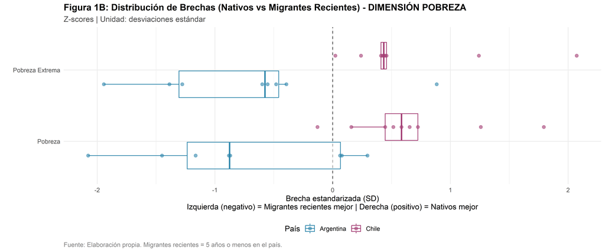

```r
p_pobreza <- datos_analisis %>%
  filter(dimension == "Pobreza", !is.na(brecha_estandarizada)) %>%
  ggplot(aes(x = indicador_clean, y = brecha_estandarizada, color = pais)) +
  geom_hline(yintercept = 0, linetype = "dashed", alpha = 0.7) +
  geom_boxplot(alpha = 0.5, position = position_dodge(0.8), outlier.shape = NA) +
  geom_jitter(position = position_dodge(0.8), alpha = 0.6, size = 2) +
  coord_flip() +
  scale_color_manual(values = c("Argentina" = "#2E86AB", "Chile" = "#A23B72")) +
  labs(
    title = "Figura 1B: Distribución de Brechas (Nativos vs Migrantes Recientes) - DIMENSIÓN POBREZA",
    subtitle = "Z-scores | Unidad: desviaciones estándar",
    x = "",
    y = "Brecha estandarizada (SD)\nIzquierda (negativo) = Migrantes recientes mejor | Derecha (positivo) = Nativos mejor",
    color = "País",
    caption = "Fuente: Elaboración propia. Migrantes recientes = 5 años o menos en el país."
  ) +
  theme_minimal(base_size = 11) +
  theme(
    plot.title = element_text(face = "bold", size = 13),
    plot.subtitle = element_text(color = "gray30"),
    plot.caption = element_text(hjust = 0, color = "gray50", size = 9),
    legend.position = "bottom"
  )

print(p_pobreza)
```

```r
ggsave("output_graficos_recientes/fig1b_brechas_pobreza_recientes.png",
       plot = p_pobreza, width = 12, height = 5, dpi = 300)
cat("✓ Gráfico guardado: output_graficos_recientes/fig1b_brechas_pobreza_recientes.png\n\n")
```

```
## ✓ Gráfico guardado: output_graficos_recientes/fig1b_brechas_pobreza_recientes.png
```

## 5.3 Dimensión Social

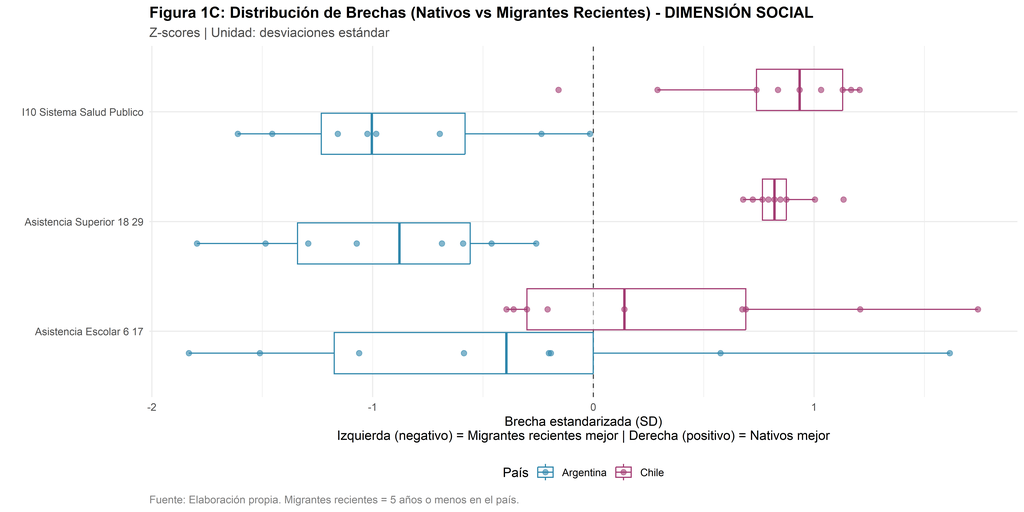

```r
p_social <- datos_analisis %>%
  filter(dimension == "Social", !is.na(brecha_estandarizada)) %>%
  ggplot(aes(x = indicador_clean, y = brecha_estandarizada, color = pais)) +
  geom_hline(yintercept = 0, linetype = "dashed", alpha = 0.7) +
  geom_boxplot(alpha = 0.5, position = position_dodge(0.8), outlier.shape = NA) +
  geom_jitter(position = position_dodge(0.8), alpha = 0.6, size = 2) +
  coord_flip() +
  scale_color_manual(values = c("Argentina" = "#2E86AB", "Chile" = "#A23B72")) +
  labs(
    title = "Figura 1C: Distribución de Brechas (Nativos vs Migrantes Recientes) - DIMENSIÓN SOCIAL",
    subtitle = "Z-scores | Unidad: desviaciones estándar",
    x = "",
    y = "Brecha estandarizada (SD)\nIzquierda (negativo) = Migrantes recientes mejor | Derecha (positivo) = Nativos mejor",
    color = "País",
    caption = "Fuente: Elaboración propia. Migrantes recientes = 5 años o menos en el país."
  ) +
  theme_minimal(base_size = 11) +
  theme(
    plot.title = element_text(face = "bold", size = 13),
    plot.subtitle = element_text(color = "gray30"),
    plot.caption = element_text(hjust = 0, color = "gray50", size = 9),
    legend.position = "bottom"
  )

print(p_social)
```

```r
ggsave("output_graficos_recientes/fig1c_brechas_social_recientes.png",
       plot = p_social, width = 12, height = 6, dpi = 300)
cat("✓ Gráfico guardado: output_graficos_recientes/fig1c_brechas_social_recientes.png\n\n")
```

```
## ✓ Gráfico guardado: output_graficos_recientes/fig1c_brechas_social_recientes.png
```

# 6 Construcción del ISDM jerárquico

## 6.1 Paso 1: Sub-índices por dimensión

```r
subindices_dimension <- datos_analisis %>%
  group_by(pais, anio, dimension) %>%
  summarise(
    # Sub-índices ABSOLUTOS (magnitud sin dirección)
    subindice_abs_normalizado = mean(abs(brecha_normalizada), na.rm = TRUE),
    subindice_abs_estandarizado = mean(abs(brecha_estandarizada), na.rm = TRUE),

    # Sub-índices DIRECCIONALES (con signo)
    subindice_dir_normalizado = mean(brecha_normalizada, na.rm = TRUE),
    subindice_dir_estandarizado = mean(brecha_estandarizada, na.rm = TRUE),

    n_indicadores = sum(!is.na(brecha_estandarizada)),
    .groups = "drop"
  )

cat("✓ Sub-índices por dimensión calculados\n\n")
```

```
## ✓ Sub-índices por dimensión calculados
```

```r
# Mostrar ejemplo
subindices_dimension %>%
  filter(anio == 2024) %>%
  select(pais, dimension, subindice_abs_estandarizado, subindice_dir_normalizado) %>%
  arrange(pais, dimension) %>%
  kable(
    caption = "Tabla 3: Ejemplo de sub-índices por dimensión (año 2024) - Migrantes Recientes",
    col.names = c("País", "Dimensión",
                  "Sub-índice Absoluto (SD)",
                  "Sub-índice Direccional (pp)"),
    digits = 3
  ) %>%
  kable_styling(bootstrap_options = c("striped", "hover"))
```

Tabla 3: Ejemplo de sub-índices por dimensión (año 2024) - Migrantes Recientes

| País | Dimensión | Sub-índice Absoluto (SD) | Sub-índice Direccional (pp) |
| --- | --- | --- | --- |
| Argentina | Laboral | 1.135 | 4.264 |
| Argentina | Pobreza | 1.074 | -6.014 |
| Argentina | Social | 1.275 | -11.646 |
| Chile | Laboral | 0.883 | 1.994 |
| Chile | Pobreza | 1.933 | 10.971 |
| Chile | Social | 0.500 | 9.642 |

## 6.2 Paso 2: Agregación final (ISDM)

```r
isdm_jerarquico <- subindices_dimension %>%
  group_by(pais, anio) %>%
  summarise(
    # ISDM ABSOLUTO: magnitud promedio de la desigualdad
    isdm_absoluto_normalizado = mean(subindice_abs_normalizado, na.rm = TRUE),
    isdm_absoluto_estandarizado = mean(subindice_abs_estandarizado, na.rm = TRUE),

    # ISDM DIRECCIONAL: dirección neta
    isdm_direccional_normalizado = mean(subindice_dir_normalizado, na.rm = TRUE),
    isdm_direccional_estandarizado = mean(subindice_dir_estandarizado, na.rm = TRUE),

    .groups = "drop"
  )

cat("✓ ISDM final calculado (para migrantes recientes)\n\n")
```

```
## ✓ ISDM final calculado (para migrantes recientes)
```

```r
# Mostrar serie temporal
isdm_jerarquico %>%
  select(pais, anio, isdm_absoluto_estandarizado, isdm_direccional_normalizado) %>%
  kable(
    caption = "Tabla 4: Serie temporal del ISDM - Nativos vs Migrantes Recientes (agregación jerárquica)",
    col.names = c("País", "Año",
                  "ISDM Absoluto (SD)",
                  "ISDM Direccional (pp)"),
    digits = 3
  ) %>%
  kable_styling(bootstrap_options = c("striped", "hover"))
```

Tabla 4: Serie temporal del ISDM - Nativos vs Migrantes Recientes (agregación jerárquica)

| País | Año | ISDM Absoluto (SD) | ISDM Direccional (pp) |
| --- | --- | --- | --- |
| Argentina | 2016 | 0.892 | -0.414 |
| Argentina | 2017 | 0.742 | -1.254 |
| Argentina | 2018 | 0.817 | -1.597 |
| Argentina | 2019 | 0.845 | -4.999 |
| Argentina | 2021 | 0.932 | -3.064 |
| Argentina | 2022 | 0.851 | -5.189 |
| Argentina | 2023 | 0.832 | -4.916 |
| Argentina | 2024 | 1.161 | -4.465 |
| Chile | 2015 | 0.526 | 1.682 |
| Chile | 2016 | 0.646 | 2.601 |
| Chile | 2017 | 0.888 | 3.520 |
| Chile | 2018 | 0.784 | 3.488 |
| Chile | 2019 | 0.679 | 3.456 |
| Chile | 2021 | 0.588 | 3.423 |
| Chile | 2022 | 0.626 | 3.391 |
| Chile | 2023 | 0.798 | 5.463 |
| Chile | 2024 | 1.105 | 7.536 |

# 7 Resultados principales

## 7.1 Promedios 2015-2024

```r
cat("\nRESULTADOS PRINCIPALES - MIGRANTES RECIENTES (PROMEDIO 2015-2024)\n")
```

```
##
## RESULTADOS PRINCIPALES - MIGRANTES RECIENTES (PROMEDIO 2015-2024)
```

```r
cat("===================================================================\n\n")
resumen <- isdm_jerarquico %>%
  group_by(pais) %>%
  summarise(
    across(starts_with("isdm_"), ~mean(.x, na.rm = TRUE)),
    .groups = "drop"
  )

# Extraer valores
arg_abs <- resumen %>% filter(pais == "Argentina") %>% pull(isdm_absoluto_estandarizado)
chl_abs <- resumen %>% filter(pais == "Chile") %>% pull(isdm_absoluto_estandarizado)
arg_dir <- resumen %>% filter(pais == "Argentina") %>% pull(isdm_direccional_normalizado)
chl_dir <- resumen %>% filter(pais == "Chile") %>% pull(isdm_direccional_normalizado)

# Tabla
resumen %>%
  select(pais, isdm_absoluto_normalizado, isdm_absoluto_estandarizado,
         isdm_direccional_normalizado, isdm_direccional_estandarizado) %>%
  kable(
    caption = "Tabla 5: ISDM promedio por país (2015-2024) - Migrantes Recientes",
    col.names = c("País",
                  "ISDM Absoluto\n(normalizado, pp)",
                  "ISDM Absoluto\n(estandarizado, SD)",
                  "ISDM Direccional\n(normalizado, pp)",
                  "ISDM Direccional\n(estandarizado, SD)"),
    digits = 3
  ) %>%
  kable_styling(bootstrap_options = c("striped", "hover"))
```

Tabla 5: ISDM promedio por país (2015-2024) - Migrantes Recientes

[output not shown]

```r
# Interpretación
cat("\n\nINTERPRETACIÓN:\n")
```

```
##
##
## INTERPRETACIÓN:
```

```r
cat("===============\n\n")
cat("1. MAGNITUD DE LA DESIGUALDAD (NATIVOS VS MIGRANTES RECIENTES):\n\n")
```

```
## 1. MAGNITUD DE LA DESIGUALDAD (NATIVOS VS MIGRANTES RECIENTES):
```

```r
dif_pct <- ((chl_abs - arg_abs) / arg_abs) * 100
pais_mayor <- ifelse(chl_abs > arg_abs, "Chile", "Argentina")
pais_menor <- ifelse(chl_abs > arg_abs, "Argentina", "Chile")

cat(sprintf("   • %s: %.3f SD\n", "Argentina", arg_abs))
```

```
##    • Argentina: 0.884 SD
```

```r
cat(sprintf("   • %s: %.3f SD\n\n", "Chile", chl_abs))
```

```
##    • Chile: 0.738 SD
```

```r
cat(sprintf("   → %s presenta %.1f%% %s desigualdad con migrantes recientes que %s\n\n",
            pais_mayor, abs(dif_pct),
            ifelse(dif_pct > 0, "MAYOR", "MENOR"),
            pais_menor))
```

[output not shown]

```r
cat("2. DIRECCIÓN DE LA DESIGUALDAD:\n\n")
```

```
## 2. DIRECCIÓN DE LA DESIGUALDAD:
```

```r
cat(sprintf("   • Argentina: %+.2f pp → Nativos %s integrados que migrantes recientes\n",
            arg_dir, ifelse(arg_dir > 0, "MEJOR", "PEOR")))
```

```
##    • Argentina: -3.24 pp → Nativos PEOR integrados que migrantes recientes
```

```r
cat(sprintf("   • Chile:     %+.2f pp → Nativos %s integrados que migrantes recientes\n\n",
            chl_dir, ifelse(chl_dir > 0, "MEJOR", "PEOR")))
```

```
##    • Chile:     +3.84 pp → Nativos MEJOR integrados que migrantes recientes
```

## 7.2 Tests estadísticos y robustez

```r
cat("\nTEST DE DIFERENCIA ENTRE PAÍSES (MIGRANTES RECIENTES)\n")
```

```
##
## TEST DE DIFERENCIA ENTRE PAÍSES (MIGRANTES RECIENTES)
```

```r
cat("======================================================\n\n")
# --- PRUEBA DE NORMALIDAD: SHAPIRO-WILK ---
cat("Prueba de normalidad Shapiro-Wilk para ISDM Absoluto:\n\n")
```

```
## Prueba de normalidad Shapiro-Wilk para ISDM Absoluto:
```

```r
sw_arg <- shapiro.test(isdm_jerarquico %>% filter(pais == "Argentina") %>% pull(isdm_absoluto_estandarizado))
sw_chl <- shapiro.test(isdm_jerarquico %>% filter(pais == "Chile")     %>% pull(isdm_absoluto_estandarizado))

cat(sprintf("  • Argentina: W = %.4f, p-valor = %.4f %s\n",
            sw_arg$statistic, sw_arg$p.value,
            ifelse(sw_arg$p.value >= 0.05,
                   "→ Distribución NORMAL (p ≥ 0.05)",
                   "→ Distribución NO normal (p < 0.05)")))
```

```
##   • Argentina: W = 0.8286, p-valor = 0.0574 → Distribución NORMAL (p ≥ 0.05)
```

```r
cat(sprintf("  • Chile:     W = %.4f, p-valor = %.4f %s\n\n",
            sw_chl$statistic, sw_chl$p.value,
            ifelse(sw_chl$p.value >= 0.05,
                   "→ Distribución NORMAL (p ≥ 0.05)",
                   "→ Distribución NO normal (p < 0.05)")))
```

```
##   • Chile:     W = 0.9239, p-valor = 0.4257 → Distribución NORMAL (p ≥ 0.05)
```

```r
normalidad_ok <- sw_arg$p.value >= 0.05 & sw_chl$p.value >= 0.05
if(normalidad_ok) {
  cat("  ✓ Ambos grupos cumplen normalidad: el test t de Student es apropiado.\n\n")
} else {
  cat("  ⚠ Al menos un grupo no cumple normalidad: considerar test no paramétrico (Wilcoxon).\n\n")
}
```

```
##   ✓ Ambos grupos cumplen normalidad: el test t de Student es apropiado.
```

```r
# --- TEST T DE STUDENT ---
cat("─────────────────────────────────────────\n")
test_t <- t.test(
  isdm_absoluto_estandarizado ~ pais,
  data = isdm_jerarquico,
  var.equal = FALSE
)

cat("Test t de Student para ISDM Absoluto:\n\n")
```

```
## Test t de Student para ISDM Absoluto:
```

```r
cat(sprintf("  • Estadístico t: %.4f\n", test_t$statistic))
```

```
##   • Estadístico t: 1.9748
```

```r
cat(sprintf("  • p-valor: %.4f\n", test_t$p.value))
```

```
##   • p-valor: 0.0679
```

```r
cat(sprintf("  • IC 95%%: [%.4f, %.4f]\n\n", test_t$conf.int[1], test_t$conf.int[2]))
```

```
##   • IC 95%: [-0.0123, 0.3049]
```

```r
if(test_t$p.value < 0.05) {
  cat("  ✓ Diferencias ESTADÍSTICAMENTE SIGNIFICATIVAS (p < 0.05)\n\n")
} else {
  cat("  ⚠ Diferencias NO significativas (p ≥ 0.05)\n\n")
}
```

```
##   ⚠ Diferencias NO significativas (p ≥ 0.05)
```

```r
# --- DIFERENCIA DE MEDIAS ---
cat("─────────────────────────────────────────\n")
cat("Diferencia de medias observada:\n\n")
```

```
## Diferencia de medias observada:
```

```r
medias <- isdm_jerarquico %>%
  group_by(pais) %>%
  summarise(
    media = mean(isdm_absoluto_estandarizado, na.rm = TRUE),
    sd    = sd(isdm_absoluto_estandarizado,   na.rm = TRUE),
    n     = n(),
    .groups = "drop"
  )

media_arg  <- medias %>% filter(pais == "Argentina") %>% pull(media)
media_chl  <- medias %>% filter(pais == "Chile")     %>% pull(media)
sd_arg     <- medias %>% filter(pais == "Argentina") %>% pull(sd)
sd_chl     <- medias %>% filter(pais == "Chile")     %>% pull(sd)
n_arg      <- medias %>% filter(pais == "Argentina") %>% pull(n)
n_chl      <- medias %>% filter(pais == "Chile")     %>% pull(n)
dif_medias <- media_arg - media_chl

cat(sprintf("  • Media Argentina: %.4f SD  (n = %d)\n", media_arg, n_arg))
```

```
##   • Media Argentina: 0.8840 SD  (n = 8)
```

```r
cat(sprintf("  • Media Chile:     %.4f SD  (n = %d)\n", media_chl, n_chl))
```

```
##   • Media Chile:     0.7377 SD  (n = 9)
```

```r
cat(sprintf("  • Diferencia (Arg - Chl): %+.4f SD\n\n", dif_medias))
```

```
##   • Diferencia (Arg - Chl): +0.1463 SD
```

```r
# --- COHEN'S D ---
cat("─────────────────────────────────────────\n")
cat("Tamaño del efecto - Cohen's d:\n\n")
```

```
## Tamaño del efecto - Cohen's d:
```

```r
sd_pooled <- sqrt(((n_arg - 1) * sd_arg^2 + (n_chl - 1) * sd_chl^2) /
                    (n_arg + n_chl - 2))
cohens_d  <- dif_medias / sd_pooled

interpretacion_d <- case_when(
  abs(cohens_d) < 0.2 ~ "efecto PEQUEÑO",
  abs(cohens_d) < 0.5 ~ "efecto PEQUEÑO-MODERADO",
  abs(cohens_d) < 0.8 ~ "efecto MODERADO",
  TRUE                ~ "efecto GRANDE"
)

cat(sprintf("  • SD pooled:  %.4f\n", sd_pooled))
```

```
##   • SD pooled:  0.1558
```

```r
cat(sprintf("  • Cohen's d:  %.4f → %s\n\n", cohens_d, interpretacion_d))
```

```
##   • Cohen's d:  0.9392 → efecto GRANDE
```

```r
cat("  Referencia: |d| < 0.2 pequeño | 0.2–0.5 pequeño-moderado | 0.5–0.8 moderado | > 0.8 grande\n\n")
```

```
##   Referencia: |d| < 0.2 pequeño | 0.2–0.5 pequeño-moderado | 0.5–0.8 moderado | > 0.8 grande
```

```r
# --- PERMUTATION TEST ---
cat("─────────────────────────────────────────\n")
cat("Permutation test (n = 10.000 permutaciones):\n\n")
```

```
## Permutation test (n = 10.000 permutaciones):
```

```r
set.seed(42)
n_perm  <- 10000
valores <- isdm_jerarquico$isdm_absoluto_estandarizado
grupos  <- isdm_jerarquico$pais

dif_obs  <- mean(valores[grupos == "Argentina"]) - mean(valores[grupos == "Chile"])
dif_perm <- replicate(n_perm, {
  g <- sample(grupos)
  mean(valores[g == "Argentina"]) - mean(valores[g == "Chile"])
})
p_perm <- mean(abs(dif_perm) >= abs(dif_obs))

cat(sprintf("  • Diferencia observada:    %+.4f SD\n", dif_obs))
```

```
##   • Diferencia observada:    +0.1463 SD
```

```r
cat(sprintf("  • p-valor permutación:     %.4f\n\n",   p_perm))
```

```
##   • p-valor permutación:     0.0715
```

```r
if(p_perm < 0.05) {
  cat("  ✓ Diferencias SIGNIFICATIVAS según permutation test (p < 0.05)\n\n")
} else {
  cat("  ⚠ Diferencias NO significativas según permutation test (p ≥ 0.05)\n\n")
}
```

```
##   ⚠ Diferencias NO significativas según permutation test (p ≥ 0.05)
```

```r
# --- RESUMEN DE ROBUSTEZ ---
cat("─────────────────────────────────────────\n")
cat("RESUMEN DE PRUEBAS:\n\n")
```

```
## RESUMEN DE PRUEBAS:
```

```r
cat(sprintf("  %-28s p = %.4f  %s\n", "Test t de Welch:",
            test_t$p.value,
            ifelse(test_t$p.value < 0.05, "✓ Significativo", "⚠ No significativo")))
```

```
##   Test t de Welch:             p = 0.0679  ⚠ No significativo
```

```r
cat(sprintf("  %-28s p = %.4f  %s\n", "Permutation test:",
            p_perm,
            ifelse(p_perm < 0.05, "✓ Significativo", "⚠ No significativo")))
```

```
##   Permutation test:            p = 0.0715  ⚠ No significativo
```

```r
cat(sprintf("  %-28s d = %.4f  %s\n", "Cohen's d:", cohens_d, interpretacion_d))
```

```
##   Cohen's d:                   d = 0.9392  efecto GRANDE
```

# 8 Análisis por dimensiones

## 8.1 Sub-índices promedio

```r
cat("\nDESIGUALDAD POR DIMENSIÓN ANALÍTICA (MIGRANTES RECIENTES)\n")
```

```
##
## DESIGUALDAD POR DIMENSIÓN ANALÍTICA (MIGRANTES RECIENTES)
```

```r
cat("==========================================================\n\n")
resumen_dimensiones <- subindices_dimension %>%
  group_by(pais, dimension) %>%
  summarise(
    subindice_abs_promedio = mean(subindice_abs_estandarizado, na.rm = TRUE),
    subindice_dir_promedio = mean(subindice_dir_normalizado, na.rm = TRUE),
    .groups = "drop"
  )

resumen_dimensiones %>%
  kable(
    caption = "Tabla 6: Sub-índices promedio por dimensión (2015-2024) - Migrantes Recientes",
    col.names = c("País", "Dimensión",
                  "Sub-índice Absoluto (SD)",
                  "Sub-índice Direccional (pp)"),
    digits = 3
  ) %>%
  kable_styling(bootstrap_options = c("striped", "hover")) %>%
  row_spec(which(resumen_dimensiones$dimension == "Laboral"), background = "#E3F2FD") %>%
  row_spec(which(resumen_dimensiones$dimension == "Pobreza"), background = "#FCE4EC") %>%
  row_spec(which(resumen_dimensiones$dimension == "Social"), background = "#FFF3E0")
```

Tabla 6: Sub-índices promedio por dimensión (2015-2024) - Migrantes Recientes

| País | Dimensión | Sub-índice Absoluto (SD) | Sub-índice Direccional (pp) |
| --- | --- | --- | --- |
| Argentina | Laboral | 0.819 | 1.588 |
| Argentina | Pobreza | 0.900 | -4.562 |
| Argentina | Social | 0.933 | -6.738 |
| Chile | Laboral | 0.773 | -6.651 |
| Chile | Pobreza | 0.667 | 3.760 |
| Chile | Social | 0.773 | 14.411 |

```r
# Ranking por país
cat("\n\nRANKING DE DIMENSIONES POR MAGNITUD DE DESIGUALDAD:\n")
```

```
##
##
## RANKING DE DIMENSIONES POR MAGNITUD DE DESIGUALDAD:
```

```r
cat("====================================================\n\n")
for(p in unique(resumen_dimensiones$pais)) {
  cat(sprintf("%s:\n", p))
  ranking <- resumen_dimensiones %>%
    filter(pais == p) %>%
    arrange(desc(subindice_abs_promedio))

  for(i in 1:nrow(ranking)) {
    cat(sprintf("  %d. %s (%.3f SD)\n",
                i, ranking$dimension[i], ranking$subindice_abs_promedio[i]))
  }
  cat("\n")
}
```

```
## Argentina:
##   1. Social (0.933 SD)
##   2. Pobreza (0.900 SD)
##   3. Laboral (0.819 SD)
##
## Chile:
##   1. Laboral (0.773 SD)
##   2. Social (0.773 SD)
##   3. Pobreza (0.667 SD)
```

## 8.2 Visualización: Barras por dimensión

```r
p_dimensiones <- ggplot(resumen_dimensiones,
                         aes(x = dimension, y = subindice_abs_promedio,
                             fill = pais)) +
  geom_col(position = "dodge", width = 0.7, alpha = 0.9) +
  geom_text(aes(label = sprintf("%.2f", subindice_abs_promedio)),
            position = position_dodge(width = 0.7),
            vjust = -0.5, size = 4, fontface = "bold") +
  scale_fill_manual(
    values = c("Argentina" = "#2E86AB", "Chile" = "#A23B72"),
    name = "País"
  ) +
  labs(
    title = "Figura 2: Desigualdad con migrantes recientes por dimensión analítica",
    subtitle = "Sub-índices absolutos promedio 2015-2024 (valores estandarizados)",
    x = "Dimensión",
    y = "Magnitud del sub-índice (SD)",
    caption = "Fuente: Elaboración propia. Valores más altos indican mayor desigualdad.\nMigrantes recientes = 5 años o menos en el país."
  ) +
  theme_minimal(base_size = 12) +
  theme(
    plot.title = element_text(face = "bold", size = 14),
    plot.subtitle = element_text(color = "gray30"),
    legend.position = "bottom",
    panel.grid.major.x = element_blank(),
    axis.text.x = element_text(size = 12, face = "bold")
  )

print(p_dimensiones)
```

[figure not shown]

```r
ggsave("output_graficos_recientes/fig2_dimensiones_barras_recientes.png",
       plot = p_dimensiones, width = 10, height = 7, dpi = 300)
cat("✓ Gráfico guardado: output_graficos_recientes/fig2_dimensiones_barras_recientes.png\n\n")
```

```
## ✓ Gráfico guardado: output_graficos_recientes/fig2_dimensiones_barras_recientes.png
```

## 8.3 Evolución temporal por dimensión

```r
p_evolucion_dim <- ggplot(subindices_dimension,
                           aes(x = anio, y = subindice_abs_estandarizado,
                               color = pais, linetype = pais)) +
  geom_line(linewidth = 1) +
  geom_point(size = 2.5, alpha = 0.7) +
  facet_wrap(~ dimension, ncol = 1, scales = "free_y") +
  scale_color_manual(
    values = c("Argentina" = "#2E86AB", "Chile" = "#A23B72"),
    name = "País"
  ) +
  scale_linetype_manual(
    values = c("Argentina" = "solid", "Chile" = "dashed"),
    name = "País"
  ) +
  labs(
    title = "Figura 3: Evolución temporal de la desigualdad con migrantes recientes por dimensión",
    subtitle = "Sub-índices absolutos estandarizados (2015-2024)",
    x = "Año",
    y = "Magnitud del sub-índice (SD)",
    caption = "Fuente: Elaboración propia. Migrantes recientes = 5 años o menos en el país."
  ) +
  theme_minimal(base_size = 12) +
  theme(
    plot.title = element_text(face = "bold", size = 14),
    plot.subtitle = element_text(color = "gray30"),
    strip.text = element_text(face = "bold", size = 12),
    legend.position = "bottom",
    panel.grid.minor = element_blank()
  )

print(p_evolucion_dim)
```

[figure not shown]

```r
ggsave("output_graficos_recientes/fig3_evolucion_dimensiones_recientes.png",
       plot = p_evolucion_dim, width = 12, height = 10, dpi = 300)
cat("✓ Gráfico guardado: output_graficos_recientes/fig3_evolucion_dimensiones_recientes.png\n\n")
```

```
## ✓ Gráfico guardado: output_graficos_recientes/fig3_evolucion_dimensiones_recientes.png
```

# 9 Evolución del ISDM total

## 9.1 Serie temporal

```r
p_evolucion <- ggplot(isdm_jerarquico,
                       aes(x = anio, y = isdm_absoluto_estandarizado,
                           color = pais, linetype = pais)) +
  geom_line(linewidth = 1.3) +
  geom_point(size = 3.5, alpha = 0.8) +
  scale_color_manual(
    values = c("Argentina" = "#2E86AB", "Chile" = "#A23B72"),
    name = "País"
  ) +
  scale_linetype_manual(
    values = c("Argentina" = "solid", "Chile" = "dashed"),
    name = "País"
  ) +
  labs(
    title = "Figura 4: Evolución del Índice de Desigualdad Migratoria (Migrantes Recientes)",
    subtitle = "ISDM Absoluto (estandarizado) - Agregación jerárquica por dimensiones",
    x = "Año",
    y = "Magnitud de la desigualdad (SD)",
    caption = "Fuente: Elaboración propia. Valores más altos indican mayor desigualdad.\nMigrantes recientes = 5 años o menos en el país."
  ) +
  theme_minimal(base_size = 13) +
  theme(
    plot.title = element_text(face = "bold", size = 15),
    plot.subtitle = element_text(color = "gray30"),
    legend.position = "bottom",
    panel.grid.minor = element_blank()
  )

print(p_evolucion)
```

[figure not shown]

```r
ggsave("output_graficos_recientes/fig4_evolucion_isdm_recientes.png",
       plot = p_evolucion, width = 12, height = 7, dpi = 300)
cat("✓ Gráfico guardado: output_graficos_recientes/fig4_evolucion_isdm_recientes.png\n\n")
```

```
## ✓ Gráfico guardado: output_graficos_recientes/fig4_evolucion_isdm_recientes.png
```

## 9.2 Comparación de promedios

```r
p_comparacion <- resumen %>%
  select(pais, isdm_absoluto_estandarizado) %>%
  ggplot(aes(x = reorder(pais, -isdm_absoluto_estandarizado),
             y = isdm_absoluto_estandarizado,
             fill = pais)) +
  geom_col(width = 0.6, alpha = 0.9) +
  geom_text(aes(label = sprintf("%.3f SD", isdm_absoluto_estandarizado)),
            vjust = -0.5, size = 5.5, fontface = "bold") +
  scale_fill_manual(
    values = c("Argentina" = "#2E86AB", "Chile" = "#A23B72"),
    guide = "none"
  ) +
  labs(
    title = "Figura 5: Desigualdad con migrantes recientes promedio por país",
    subtitle = "ISDM Absoluto (estandarizado) promedio 2015-2024",
    x = "",
    y = "Magnitud de la desigualdad (SD)",
    caption = "Fuente: Elaboración propia. Agregación jerárquica por dimensiones.\nMigrantes recientes = 5 años o menos en el país."
  ) +
  theme_minimal(base_size = 13) +
  theme(
    plot.title = element_text(face = "bold", size = 15),
    plot.subtitle = element_text(color = "gray30"),
    axis.text.x = element_text(size = 14, face = "bold"),
    panel.grid.major.x = element_blank()
  )

print(p_comparacion)
```

[figure not shown]

```r
ggsave("output_graficos_recientes/fig5_comparacion_paises_recientes.png",
       plot = p_comparacion, width = 10, height = 7, dpi = 300)
cat("✓ Gráfico guardado: output_graficos_recientes/fig5_comparacion_paises_recientes.png\n\n")
```

```
## ✓ Gráfico guardado: output_graficos_recientes/fig5_comparacion_paises_recientes.png
```

# 10 Conclusiones

```r
cat("\n## Hallazgos principales (Migrantes Recientes)\n\n")
```

## 10.1 Hallazgos principales (Migrantes Recientes)

```r
cat("### 1. Magnitud de la desigualdad con migrantes recientes\n\n")
```

### 10.1.1 1. Magnitud de la desigualdad con migrantes recientes

```r
cat(sprintf("- **%s** presenta %.1f%% %s desigualdad con migrantes recientes que **%s**\n",
            pais_mayor, abs(dif_pct),
            ifelse(dif_pct > 0, "mayor", "menor"),
            pais_menor))
```

[output not shown]

```r
cat(sprintf("- ISDM promedio: %s = %.3f SD vs. %s = %.3f SD\n\n",
            pais_mayor, max(arg_abs, chl_abs),
            pais_menor, min(arg_abs, chl_abs)))
```

- ISDM promedio: Argentina = 0.884 SD vs. Chile = 0.738 SD

```r
cat("### 2. Desigualdad por dimensión (migrantes recientes)\n\n")
```

### 10.1.2 2. Desigualdad por dimensión (migrantes recientes)

```r
ranking_dimensiones <- resumen_dimensiones %>%
  group_by(pais) %>%
  arrange(desc(subindice_abs_promedio)) %>%
  mutate(ranking = row_number()) %>%
  ungroup()

for(p in unique(ranking_dimensiones$pais)) {
  cat(sprintf("**%s:**\n\n", p))
  dims <- ranking_dimensiones %>% filter(pais == p)
  for(i in 1:nrow(dims)) {
    cat(sprintf("%d. %s (%.3f SD)\n",
                dims$ranking[i], dims$dimension[i], dims$subindice_abs_promedio[i]))
  }
  cat("\n")
}
```

**Argentina:**

1. Social (0.933 SD)
2. Pobreza (0.900 SD)
3. Laboral (0.819 SD)

**Chile:**

1. Laboral (0.773 SD)
2. Social (0.773 SD)
3. Pobreza (0.667 SD)

```r
cat("### 3. Significancia estadística\n\n")
```

### 10.1.3 3. Significancia estadística

```r
if(test_t$p.value < 0.05) {
  cat(sprintf("- Las diferencias entre países son **estadísticamente significativas** (p = %.4f)\n\n",
              test_t$p.value))
} else {
  cat(sprintf("- Las diferencias NO alcanzan significancia estadística (p = %.4f)\n\n",
              test_t$p.value))
}
```

- Las diferencias NO alcanzan significancia estadística (p = 0.0679)

```r
cat("### 4. Implicaciones del enfoque en migrantes recientes\n\n")
```

### 10.1.4 4. Implicaciones del enfoque en migrantes recientes

```r
cat("- Este análisis complementa el ISDM general al enfocarse en el subgrupo más vulnerable\n")
```

- Este análisis complementa el ISDM general al enfocarse en el subgrupo más vulnerable

```r
cat("- Las brechas con migrantes recientes suelen ser mayores debido a menor tiempo de integración\n")
```

- Las brechas con migrantes recientes suelen ser mayores debido a menor tiempo de integración

```r
cat("- Las diferencias entre países pueden reflejar políticas de acogida e integración temprana\n")
```

- Las diferencias entre países pueden reflejar políticas de acogida e integración temprana

```r
cat("- El análisis por dimensiones permite identificar áreas prioritarias de intervención\n\n")
```

- El análisis por dimensiones permite identificar áreas prioritarias de intervención

# 11 Información de sesión

```r
cat("\n## Software utilizado\n\n")
```

```
##
## ## Software utilizado
```

```r
cat("**R version:**", R.version.string, "\n\n")
```

```
## **R version:** R version 4.5.2 (2025-10-31 ucrt)
```

```r
cat("**Paquetes principales:**\n")
```

```
## **Paquetes principales:**
```

```r
cat("  • tidyverse:", as.character(packageVersion("tidyverse")), "\n")
```

```
##   • tidyverse: 2.0.0
```

```r
cat("  • knitr:", as.character(packageVersion("knitr")), "\n")
```

```
##   • knitr: 1.51
```

```r
cat("  • kableExtra:", as.character(packageVersion("kableExtra")), "\n\n")
```

```
##   • kableExtra: 1.4.0
```

```r
cat("**Fecha de generación:**", format(Sys.time(), "%Y-%m-%d %H:%M:%S"), "\n")
```

```
## **Fecha de generación:** 2026-02-22 20:31:45
```

**Documento generado automáticamente mediante R Markdown**  
**Autora:** Natalia Debandi  
**Análisis:** Brechas entre nativos y migrantes recientes (5 años o menos en el país)

*Nota: Todos los gráficos han sido guardados en formato PNG de alta resolución (300 dpi) en la carpeta `output_graficos_recientes/` para su uso en publicaciones.*